# Data 101

[Alex Leslie](https://english.rutgers.edu/cb-profile/ahl80.html)

10/13/2019

Welcome to Data 101! In the humanities and social sciences we often find ourselves with data - that is, a set of observations that can be organized into consistent categories for the sake of understanding broader patterns or systems of relation. In this workshop you’ll learn how to carry out some of the essential operations for organizing, transforming, and analyzing your data.

We often use structures like spreadsheets (like Excel documents), comma-separated values (.csv files), and other types of tabular formats in order to organize data in a way that is accessibly represented for human users and easily processed by computers or programming languages. Data is considered “tidy” when it meets these three conditions:[^1]

- Each variable must have its own column
- Each observation must have its own row
- Each value must have its own cell

Before doing any computational analysis, it’s essential to get our data into an organization that is tidy. The data I’ve selected is already quite tidy, but several of the functions here can save a ton of time if you have additional tidying to do before you can begin working with your own.

## Getting Started in RStudio

Don’t panic: you’re in RStudio, an environment that makes coding in R more transparent. Your window is divided into four segments. In the upper right, you’ll see the environment: this displays all the objects you currently have loaded into memory. In the upper left, you’ll see the script editor: this is the place to work on code that you’re currently writing (or borrowing from elsewhere!). To run code in code chunks (the grey chunks), you can either press Ctrl+Enter to run single lines or click the green arrow to run the entire chunk. In the lower left, you’ll see the console: this is where code actually executes and where the output prints. In the lower right, you’ll see a few different things. The “Files” tab shows whatever files live in the current directory (or, in RStudio Cloud, whatever you’ve uploaded); if you run any plots, they’ll show up in the “Plots” tab; you can also get help in the “Help” tab.

First, let’s read in our data into our environment. We’ll do that by using a function, `read.csv`, to read in a .csv file and assign that data (using `<-`) to an object in our environment with whatever name we’d like (“transactions”). (If you want to try working with your own spreadsheet, change the file name and then change the object name to “all_records”.)

```r
transactions <- read.csv("transaction.csv", skip=1)
books <- read.csv("book.csv", skip=1)
```

We’ll use `inner_join` to join our transactions data frame and our books data frame by each book’s Accession Number. This operation is a bit more advanced, but I want to demonstrate it before we get started. Wherever there is a row in the first data frame that shares the same value in the specified column as a row in the second data frame, `inner_join` will combine those two rows. If there are multiple rows with shared values, `inner_join` will generate all possible combinations (e.g., multiple transactions for the same book). `inner_join` will simply drop any row for which there isn’t a shared value in each data frame (e.g., a book that was never checked out).

```r
all_records <- inner_join(transactions, books, by="Accession..")
# the number of observations isn't the same because some books aren't in books.csv

all_records[] <- lapply(all_records, as.character)
# this is just to make sure everything is in the more convenient character format
```

So what do we have here? In RStudio you can easily inspect data in the environment without coding. Just click on one of the objects, and a viewer window will show up in the script editor. This should look much like what your data looked like as a spreadsheet: note that we have values in each cell that are each associated with a row, corresponding to an observation, and a column, corresponding to a variable. In R programming, we call this format a data frame.

## Getting Familiar with Data Frames

There are two simple data types: numerical and categorical. Numerical data can be either discrete (1, 3, 1891) or continuous (14.5, 2.333). Categorical data can entail a strictly-defined range of possible values (letters of the English alphabet, party membership in the British parliament), but it can also be much more extensive (shades of color, books published in the Northern Hemisphere).

Our data frame includes variables of numerical data (such as Transaction Date and Accession number), as well as categorical (such as Title or Borrower Name). It also currently includes a variable or two that seem to contain a bit of both (such as Author): ideally, we’ll want to separate those out later.

R is handy because it allows us to select, inspect, and mutate our data in a wide range of possible ways. We can select single values from a data frame by indicating their specific position within it. For example, let’s say we wanted to know the name of the first book checked out. We know that the first transaction is the first observation in our data frame because our observations are arranged chronologically by transaction date; we also know Title is the third variable in our data frame. So all we need to do is *index* that exact position, row one column three, into all_records by using brackets.

```r
all_records[1,3]
```

```
## [1] "Wild men and wild beasts : or, Scenes in camp and jungle"
```

Note that when we aren’t using `<-` to assign the results of a line of code to an object in memory, R will simply produce the results in the console. This is usually how we write lines of code when we’re just trying to find a specific piece of information or testing to make sure something works.

If we wanted to see all values belonging to a particular observation, we would simply index the number of the row followed by a comma, without a second number.

```r
all_records[1,]
```

|  | Transaction.Date.YYYYMMDD. | Accession.. | Title.x | Borrower.Name | Patron.. | Listed.Patron.Name | Transaction.Comments | Accession.Date..YYYYMMDD. | Title.y | Author | X..Times.Checked.Out |
| --- | --- | --- | --- | --- | --- | --- | --- | --- | --- | --- | --- |
| 1 | 18911106 | 1299 | Wild men and wild beasts : or, Scenes in camp and jungle | Fremont Miller | 2886 | Fremont Miller |  | 18750313 | Wild men and wild beasts : or, Scenes in camp and jungle | Cumming, Gordon, Lt. Col. | 4 |

```r
all_records[,3][1:8]
```

```
## [1] "Wild men and wild beasts : or, Scenes in camp and jungle"
## [2] "The country of the dwarfs"
## [3] "Lost in the jungle : narrated for young people."
## [4] "Adventures on the great hunting grounds of the world."
## [5] "The Atlantic monthly : a magazine of literature, science, art and politics."
## [6] "Les miseÌ\201rables."
## [7] "Crusoe's island : a ramble in the footsteps of Alexander Selkirk : with sketches of adventure in California and Washoe."
## [8] "Belle Scott; or, Liberty overthrown! : a tale for the crisis."
```

But since variables (should!) have names, we can achieve the same result more legibly by using the `$` operator followed by the name of the desired variable; the results are exactly the same.

```r
all_records$Title.x[1:8]
```

```
## [1] "Wild men and wild beasts : or, Scenes in camp and jungle"
## [2] "The country of the dwarfs"
## [3] "Lost in the jungle : narrated for young people."
## [4] "Adventures on the great hunting grounds of the world."
## [5] "The Atlantic monthly : a magazine of literature, science, art and politics."
## [6] "Les miseÌ\201rables."
## [7] "Crusoe's island : a ramble in the footsteps of Alexander Selkirk : with sketches of adventure in California and Washoe."
## [8] "Belle Scott; or, Liberty overthrown! : a tale for the crisis."
```

These particular inspections may seem unimportant, but they’re the bread and butter of the more complex operations we’ll carry out shortly.

For now, “Title.x” is a pretty crumby name: fixing that sounds as good a place to start as any.

## Basic Organizational Operations

Now that we’re a bit more comfortable with the structure of the data frame in R, it’s time to learn how to make use of it. The `dplyr` package gives us seven basic functions for organizing and analyzing data frames.

| Function | Use |
| --- | --- |
| `rename` | Rename a variable (column), new title = old title |
| `select` | Select variables (columns) to include / exclude (with `-`) |
| `arrange` | Arrange the order of observations, adding `desc` for descending order |
| `filter` | Filter observations (rows) based on their values for a specified variable (using `<`, `>`, `==`, or `!=`) |
| `group_by` | Put observations into groups by their values in a specified variable, for a subsequent `summarize` call |
| `summarize` | Summarize data by groups, based on preceding `group_by` call, one row for each group |
| `mutate` | Create a new variable in a data frame by mutating existing variable(s), new variable = mutation operation |

We’ll also be using the piping operator, `%>%`, which allows us to pipe the output of one function directly into the next: this allows us to make our code clearer and more concise. Think of it like pouring our data through a series of sifters with progressively smaller withes.

First, let’s rename some of these ugly variable (column) names with the `rename` function. Note that `<-` is overwriting all_records with the new variable names: without `<-` R would simply print it differently in the console without actually changing all_records. If you’re working with your own data, find one or more that you can change, even if just temporarily.

```r
all_records <- all_records %>%
  rename("Accession" = "Accession..") %>%
  rename("Title" = "Title.x")
```

All the piping operator does in those previous lines is tell the next function that we’re still working with the all_records data frame. If we wanted to, we could achieve the exact same result by writing out each `rename` call separately: even with only two operations you can see the added redundancy. As it is, these lines won’t run because we’ve already changed the variable names.

```r
all_records <- rename(all_records, "Accession" = "Accession..")
all_records <- rename(all_records, "Title" = "Title.x")
```

Our data frame has two variables for titles that each contain the exact information as a result of our `inner_join`. We can remove the duplicate and any other variables we don’t want by using a negative operator `-` with `select`.

```r
all_records <- all_records %>%
  select(-Title.y) %>%
  select(-Patron..) %>%
  select(-X..Times.Checked.Out) %>%
  select(-Transaction.Comments)
```

Remember you can always click on the name of your object in the RStudio environment if you want to check up on how it looks!

We can also systematically transform, or mutate, values within the data frame. For this we’ll use `mutate`, a function that will allow us to declare a new variable within the data frame based on an existing variable. As with `rename`, the new variable comes first and the existing one comes second. You may have noticed that our dates are currently a bit of an eyesore: let’s mutate all the Transaction and Accession dates at once into a format that’s more readable for both us and R.

```r
all_records <- all_records %>%
  mutate(Transaction.Date = as.Date(Transaction.Date.YYYYMMDD., "%Y%m%d")) %>%
  select(-Transaction.Date.YYYYMMDD.) %>%
  mutate(Accession.Date = as.Date(Accession.Date..YYYYMMDD., "%Y%m%d")) %>%
  select(-Accession.Date..YYYYMMDD.)
```

Since this mutation is just reformating rather than creating new data, we can remove the old variable with `select`. There are all kinds of possible `mutate` uses: variables to be turned into percentages, numeric variables to find the `sum` of, variables containing words you want to `paste` together into one, etc. If you’re working with your own data, see if you can identify a basic mutation to make. We may, for instance, want certain text fields to be in all lower-case, since most functions in R are case sensitive by default.

```r
all_records <- all_records %>%
  mutate(Lower.Title = tolower(Title))
```

Now that these dates are properly formatted, we can use `mutate` to generate new information. How old was each book when it was checked out? Before we run anything on all of our data, let’s run a quick test by indexing only the first value in each column (this is often good practice when coding):

```r
all_records$Transaction.Date[1] - all_records$Accession.Date[1]
```

```
## Time difference of 6082 days
```

Easy enough! We’ll just make sure to change the result to a plain number using `as.numeric` for ease of use. If we wanted to store Book Age in years, what would we have to add?[^2]

```r
all_records <- all_records %>%
  mutate(Book.Age = as.numeric(Transaction.Date - Accession.Date))
```

`select` is only for selecting variables/columns. When we want to identify observations/rows, however, we `filter`. `filter` is particularly handy when working with numeric (or pseudo-numeric) data. Here, for example, we can filter out all observations with transaction dates earlier than (less than) January 1, 1892.

```r
records_before_1892 <- all_records %>%
  filter(Transaction.Date < "1892-01-01")
```

Right now, all_records is arranged by transaction date. That’s swell, but we may wish to change that. This is where the `arrange` function comes in.

```r
records_by_borrower <- all_records %>%
   arrange(Borrower.Name)
```

Simple enough!

## Summarizing Data

So far we’ve explored a number of functions for better structuring our data (with `rename`, `select`, and `arrange`), identifying particular subsets of our data (with `filter`), and even extracting additional variables from the data we already have (with `mutate`). Most analysis, however, involves summarizing data: that is, quantifying particular patterns or tendencies. For this, we’ll want to utilize the powerful one-two punch of `group_by` and `summarize`.

Which authors were checked out the most? To determine this, we’ll group all of our observations by the Author variable (with `group_by`) and then `summarize` the number (`n`) of observations in each group as a new variable, Total. For ease of use, we’ll save this as a new data frame, top_authors. Finally, we’ll `arrange` that data frame by the Total number of times their books were checked out (rather than the alphabetical default).[^3] If you’re working with your own data, just change the variable that you `group_by`.

```r
top_authors <- all_records %>%
  group_by(Author) %>%
  summarize(Total=n()) %>%
  arrange(desc(Total))

top_authors
```

| Author | Total |
| --- | --- |
|  | 9157 |
| Alger, Horatio, 1832-1899. | 8836 |
| Fosdick, Charles Austin, 1842-1915. | 7399 |
| Adams, William T. â\200¡q (William Taylor), 1822-1897. | 5050 |
| Finley, Martha, 1828-1909. | 4734 |
| Ellis, Edward Sylvester, 1840-1916. | 2593 |
| Roe, Edward Payson, 1838-1888. | 2484 |
| Crawford, F. Marion (Francis Marion), 1854-1909. | 2116 |

There are two things to note here. First, our analysis is only as clean as our data. If an author’s name is spelled inconsistently in our initial data, we will have multiple results, corresponding to each spelling of the author’s name.

Second, the only variables retained in any operation ending with `summarize` are the ones explicitly specified for summary (in this case, Author and Total). We might, however, want to have a slightly less sweeping summary, such as one that groups observations first by Author and then by Text. In other words, we’re making a group for each author and then a group for each text within each of those author groups, whose observations we then summarize into a numeric total.

```r
top_titles <- all_records %>%
  group_by(Author, Title) %>%
  summarize(Total=n()) %>%
  arrange(desc(Total))

top_titles
```

| Author | Title | Total |
| --- | --- | --- |
|  | Harper's young people. | 1508 |
|  | Lippincott's monthly magazine. | 912 |
|  | St. Nicholas. | 910 |
|  | Harper's new monthly magazine. | 849 |
|  | The Century illustrated monthly magazine. | 740 |
| Mary Mapes Dodge | St. Nicholas. | 633 |
|  | Wide awake. | 440 |
| Alger, Horatio, 1832-1899. | The young adventurer : or, Tom's trip across the plains. | 422 |
| Finley, Martha, 1828-1909. | Elsie Dinsmore. | 422 |
| Alcott, Louisa May, 1832-1888. | Under the lilacs. | 386 |

Order matters here. Try reversing Author and Title and running the code again; what is the difference?

Hm, periodicals are gumming up the works. If we wanted to clear them out, what additional line of code would we need?[^4]

We’ve been trying to quantify our data based on shared variables, but repeat observations are often of interest too. For example, how many times does each borrower check out the same book?

```r
renewals <- all_records %>%
  group_by(Borrower.Name, Title) %>%
  summarize(Total=n())
```

Click on this new object in the RStudio environment. There’s a lot of information here. If we indeed wanted this data frame to include only observations in which the same person checked out the same book more than once, what would we have to add? If we then wanted to sort our data by the number of checkouts, what would we have to add?[^5]

## Searches and Regular Expressions

Earlier, we were able to filter observations based on numeric or quantitative variables using `filter`. Now, it is possible to siphon off categorical or qualitative data using tools we’ve already introduced: if we had the exact value in the exact manner in which it appeared in our data we could use `filter` to obtain them, and if we were interested sorting into categories we could rely on the default alphabetization of `arrange`. But when working with variables that predominantly contain long character strings - like descriptions, sentences, tweets, long book titles, etc. - it is sometimes valuable to search for particular terms.

Let’s say we wanted to find all the observations (rows) that have a particular value for a particular variable (column): in this case, the number of books checked out by a single author. We might use `filter` so long as we have the exact name of the desired Author, for example:

```r
all_records %>%
  filter(Author == "Howells, William Dean, 1837-1920.")
```

| Accession | Title | Borrower.Name | Listed.Patron.Name | Author | Transaction.Date | Accession.Date | Lower.Title | Book.Age |
| --- | --- | --- | --- | --- | --- | --- | --- | --- |
| 1270 | Venetian life. | Mrs Carrie Snyder | Mrs. Carrie Snyder | Howells, William Dean, 1837-1920. | 1892-02-08 | 1875-03-13 | venetian life. | 6176 |
| 8414 | The shadow of a dream : a story. | Mr. S. B. Garrett | S. B. Garrett | Howells, William Dean, 1837-1920. | 1894-11-12 | 1892-10-19 | the shadow of a dream : a story. | 754 |
| 8415 | The lady of the Aroostook. | Maude Culvert | Maude Culver | Howells, William Dean, 1837-1920. | 1894-12-07 | 1892-10-19 | the lady of the aroostook. | 779 |
| 8415 | The lady of the Aroostook. | Cecil Kursted | Cecil Keirstead | Howells, William Dean, 1837-1920. | 1894-12-14 | 1892-10-19 | the lady of the aroostook. | 786 |
| 8414 | The shadow of a dream : a story. | Mrs F. M. Mercer | Mrs. F. M. Mercer | Howells, William Dean, 1837-1920. | 1894-12-15 | 1892-10-19 | the shadow of a dream : a story. | 787 |
| 8410 | A hazard of new fortunes : a novel. | Campbell Keirstead | Campbell Keirstead | Howells, William Dean, 1837-1920. | 1894-12-26 | 1892-10-19 | a hazard of new fortunes : a novel. | 798 |
| 8411 | A hazard of new fortunes : a novel. | Cecil Kiersted | Cecil Keirstead | Howells, William Dean, 1837-1920. | 1894-12-26 | 1892-10-19 | a hazard of new fortunes : a novel. | 798 |
| 8415 | The lady of the Aroostook. | Mrs. Minnie Thomas | Minnie Thomas | Howells, William Dean, 1837-1920. | 1895-01-08 | 1892-10-19 | the lady of the aroostook. | 811 |

But what if some of our observations record Howells’ lifespan differently - as, in fact, some of them do? What we want is a search that can locate just part of the value. To do that, we’ll use an R function, `grep`, that searches for an exact character pattern within a vector. If you’re working with your own data, try searching an equivalent name, title, or place name variable. (I’ll index the results so that we only see the first eight.)

```r
grep("Howells, William", all_records$Author)[1:8]
```

```
## [1] 2514 3425 3894 5195 6465 7962 8450 8495
```

This gives us a long list of numbers. What are these numbers? They’re the position of each hit in `all_records$Author`; in other words, they correspond to each observation or row in our data frame containing the characters “Howells, William” in the Author variable. What we actually want to see is all the information pertaining to each observation: to do so, we’ll index those positions - with the same code - into the data frame (using brackets and a comma followed by nothing in order to get the entire row for each hit):

```r
all_records[grep("Howells, William", all_records$Author),]
```

|  | Accession | Title | Borrower.Name | Listed.Patron.Name | Author | Transaction.Date | Accession.Date | Lower.Title | Book.Age |
| --- | --- | --- | --- | --- | --- | --- | --- | --- | --- |
| 2514 | 1270 | Venetian life. | Mrs Carrie Snyder | Mrs. Carrie Snyder | Howells, William Dean, 1837-1920. | 1892-02-08 | 1875-03-13 | venetian life. | 6176 |
| 3425 | 7015 | Venetian life. | Maggie Driscoll | Clyde Leager | Howells, William Dean, â\200¡d 1837-1920. | 1892-03-04 | 1889-09-28 | venetian life. | 888 |
| 3894 | 7015 | Venetian life. | Maggie Driscoll | Clyde Leager | Howells, William Dean, â\200¡d 1837-1920. | 1892-03-18 | 1889-09-28 | venetian life. | 902 |
| 5195 | 7015 | Venetian life. | Kate Garst | Katie Garst | Howells, William Dean, â\200¡d 1837-1920. | 1892-04-30 | 1889-09-28 | venetian life. | 945 |
| 6465 | 8414 | The shadow of a dream : a story. | Mr. S. B. Garrett | S. B. Garrett | Howells, William Dean, 1837-1920. | 1894-11-12 | 1892-10-19 | the shadow of a dream : a story. | 754 |
| 7962 | 8415 | The lady of the Aroostook. | Maude Culvert | Maude Culver | Howells, William Dean, 1837-1920. | 1894-12-07 | 1892-10-19 | the lady of the aroostook. | 779 |
| 8450 | 8415 | The lady of the Aroostook. | Cecil Kursted | Cecil Keirstead | Howells, William Dean, 1837-1920. | 1894-12-14 | 1892-10-19 | the lady of the aroostook. | 786 |
| 8495 | 8414 | The shadow of a dream : a story. | Mrs F. M. Mercer | Mrs. F. M. Mercer | Howells, William Dean, 1837-1920. | 1894-12-15 | 1892-10-19 | the shadow of a dream : a story. | 787 |

See how useful our initial exercises with indexing have become? This certainly looks more complex, but it’s just making use of the same basic principles. Any time we have a subset of positions generated by functions like `grep`, all we need to do is break out the brackets and commas.

We can make our searches even more freely. For example, we could just as easily carry out the same operation but for all books that contain the word “adventure” in their titles. (Because `grep` is only concerned with matching the exact character pattern and nothing outside the quotation marks, it will return values that include “adventures” or “adventured” but not “adventuring”).

```r
all_records[grep("adventure", all_records$Title),]
```

|  | Accession | Title | Borrower.Name | Listed.Patron.Name | Author | Transaction.Date | Accession.Date | Lower.Title | Book.Age |
| --- | --- | --- | --- | --- | --- | --- | --- | --- | --- |
| 7 | 1245 | Crusoe's island : a ramble in the footsteps of Alexander Selkirk : with sketches of adventure in California and Washoe. | Wilber Sutton | Wilbur Sutton | Browne, J. Ross (John Ross), 1821-1875. | 1891-11-06 | 1875-03-13 | crusoe's island : a ramble in the footsteps of alexander selkirk : with sketches of adventure in california and washoe. | 6082 |
| 20 | 2467 | Modern chivalry : or the adventures of Captain Farrago and Teague O'Regan. | George Thompson | Geo. Thompson | Brackenridge, H. H. (Hugh Henry), 1748-1816. | 1891-11-06 | 1876-02-19 | modern chivalry : or the adventures of captain farrago and teague o'regan. | 5739 |
| 21 | 548 | Dikes and ditches, or, Young America in Holland and Belgium : a story of travel and adventure. | Roy Martin | Roy Martin | Adams, William T. â\200¡q (William Taylor), 1822-1897. | 1891-11-06 | 1875-03-13 | dikes and ditches, or, young america in holland and belgium : a story of travel and adventure. | 6082 |
| 24 | 603 | The young wrecker of the Florida reef, or, The trials and adventures of Fred Ransom. | Morris Wolff | Morris Wolff | Bache, Richard Meade. | 1891-11-07 | 1875-03-13 | the young wrecker of the florida reef, or, the trials and adventures of fred ransom. | 6083 |
| 38 | 973 | Omoo : a narrative of adventures in the South Seas. | Max Bishop | Max Bishop | Melville, Herman, 1819-1891. | 1891-11-07 | 1875-03-13 | omoo : a narrative of adventures in the south seas. | 6083 |
| 75 | 6578 | Life and adventures of Robinson Crusoe. | Ashley Hemingray | Ashley Hemingray | Defoe, Daniel, 1661?-1731. | 1891-11-09 | 1889-09-28 | life and adventures of robinson crusoe. | 772 |
| 91 | 7218 | Salt water; or, The sea life and adventures of Neil D'Arcy, the midshipman. | Mrs. L. L. Kizer | Laura Kiser | Kingston, William Henry Giles, 1814-1880. | 1891-11-10 | 1890-06-23 | salt water; or, the sea life and adventures of neil d'arcy, the midshipman. | 505 |
| 94 | 3924 | The North Pole : and Charlie Wilson's adventures in search of it. | Girtie Horlocher | Mrs. David Bour | Frost, Thomas, 1821-1908. | 1891-11-10 | 1883-11-20 | the north pole : and charlie wilson's adventures in search of it. | 2912 |

As earlier mentioned, our data frame has some variables that mix numeric and categorical data, such as Author, which includes an Author’s name as well as the years of their birth and death. Separating these three pieces of data into three distinct variables may not be strictly necessary, but it could be helpful.

Since we’re looking to create a new variable based on an existing one, we’re definitely going to want to use `mutate`. How exactly are we looking to `mutate`? We’re not looking for an exact, pre-determined character string: we’re looking for a certain pattern of characters, such as a four digit number. Let’s look at the values for the Author variable again more closely for any regular patterns. Here’s what we know:

- Each entry begins with a name composed of characters, but the length of that name varies (and sometimes includes a nom de plume in parentheses).
- This followed by a four-digit number representing year of birth.
- But there is some variance in what separates name from birth: sometimes just a comma, sometimes a comma and a symbol.
- Year of birth, however, is always followed by a dash, followed by a four-digit number representing year of death.
- Sometimes year of death is followed by a period, but not always.

In other words, we’re looking for something that follows a regular pattern and occupies a regular position within each value. The solution is a *regular expression*: an expression that represents a textual pattern rather than a specific string of text.

Within a regular expression, certain character symbols act as metacharacters, carrying special meaning. For example, `\\d` designates any digit whereas `\\w` designates any letter; if either of these are immediately followed by curled brackets and a number, such as `{4}`, we are telling the function to locate four digits or characters, respectively. We won’t go into detail with regular expressions, as this would require an additional workshop in itself; rather, my aim is simply to introduce the concept and gesture towards its considerable utility.[^6]

Since we’re trying to substitute out the desired text rather than simply locate it, we’ll need to use `gsub` instead of `grep`.

```r
all_records <- all_records %>%
  mutate(Author.Death = as.numeric(gsub("^.*-(\\d{4})", "\\1", Author)))
```

With regular expressions, one can remove unwanted punctuation, flip forename-surname order, correct semi-consistent errors, search for variant spellings at the same time, and much more in order to carry out more efficient and nuanced tidying or analysis.

## Visualization

Another great benefit of working with data in R is that one can easily transition from analysis to visualization, without switching software, changing files, or redoing work. While we don’t have time to go into the particulars of visualization in R, I want to briefly gesture towards the possibilities here.

For example, we can easily generate a quick graph of the top_authors data frame we made earlier:

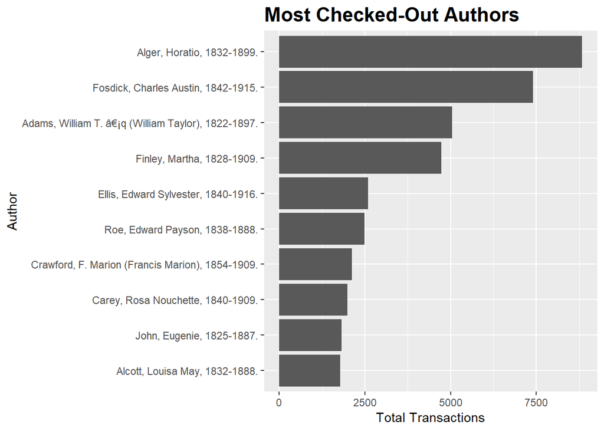

```r
top_authors[2:11,] %>%
  ggplot(aes(x=reorder(Author, Total), y=Total)) +
  geom_bar(stat="identity") +
  coord_flip() +
  ggtitle("Most Checked-Out Authors") +
  theme(plot.title = element_text(face="bold", size=rel(1.5))) +
  labs(x="Author", y="Total Transactions")
```

Most of this code is just cosmetic. Based on what we’ve done so far and what you can intuit from the names of functions, see if you can read it.

Sometimes visualization can help us see additional areas for analysis. For example, let’s simply make a timeline of all transactions.

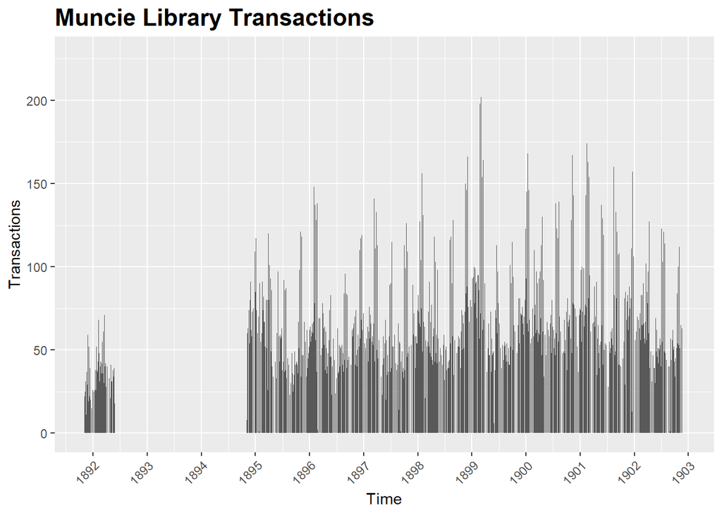

```r
all_records %>%
  ggplot(aes(x=Transaction.Date)) +
  geom_bar() +
  scale_x_date(date_breaks = "year", date_labels=("%Y")) +
  labs(x="Time", y="Transactions") +
  ggtitle("Muncie Library Transactions") +
  theme(plot.title = element_text(face="bold", size=rel(1.5))) +
  theme(axis.text.x = element_text(angle = 45, hjust = 1))
```

There’s an important moral here: visualization is never the end of analysis. Whatever results our computational analysis produces, visual or otherwise, we must then utilize for further analysis.

If you’d like to keep the changes you made to your data frame today, don’t forget to save it:

```r
write.csv(all_records, "name_this_file.csv")
```

Finally, we would really appreciate it if you took a minute to [fill out our brief feedback survey](https://rutgers.ca1.qualtrics.com/jfe/form/SV_a3itiZN18dY3fc9).

If you’d like to look at this workshop in more detail or run the code yourself, visit https://github.com/azleslie/Data101.

Thanks for participating!

## Appendix: Other Useful Functions for Data Transformation

Useful as they are, the functions introduced in this workshop are only the tip of the iceberg. Combined together, they can carry out extremely nuanced operations on data. But large scale transformations of data often require other, more efficient functions.

First, let’s circle back to one of the first tasks in this workshop: joining data frames together by columns. All of these functions combine two data frames by specified column(s), but they do so a bit differently.

| Function | Use |
| --- | --- |
| `left_join` | Returns all rows from the first data frame and all columns from both; rows in the first data frame with no shared value in the second will have NA vlaues in the columns from the second |
| `inner_join` | Returns only rows for which there is a shared value in both data frames; where there are multiple shared values, returns all combinations of rows |
| `full_join` | Returns all rows from each data frame; rows without matching values in the other data frame will have NA values |
| `anti_join` | Returns all rows from the first data frame for which there are no matching values in the second |

It is also possible to combine data frames by multiple variables by making a vector of the variable names within the join function:

```r
inner_join(transactions[1:3,], books, by=c("Accession..", "Title"))
```

| Transaction.Date.YYYYMMDD. | Accession.. | Title | Borrower.Name | Patron.. | Listed.Patron.Name | Transaction.Comments | Accession.Date..YYYYMMDD. | Author | X..Times.Checked.Out |
| --- | --- | --- | --- | --- | --- | --- | --- | --- | --- |
| 18911106 | 1299 | Wild men and wild beasts : or, Scenes in camp and jungle | Fremont Miller | 2886 | Fremont Miller |  | 18750313 | Cumming, Gordon, Lt. Col. | 4 |
| 18911106 | 7212 | The country of the dwarfs | Morris Wolff | 2889 | Morris Wolff |  | 18900623 | Du Chaillu, Paul B. (Paul Belloni), 1835-1903. | 10 |
| 18911106 | 2058 | Lost in the jungle : narrated for young people. | Willie Kemper | 1462 | W. W. Stuart |  | 18750527 | Du Chaillu, Paul Belloni, 1831-1903. | 7 |

More common than joining, however, is stacking or binding data frames by row, for which there is another family of functions. Note that all variable names must be the same in order for these functions to work.

| Function | Use |
| --- | --- |
| `rbind` | Returns all rows from each data frame |
| `intersect` | Returns only rows that appear in both data frames |
| `union` | Returns rows that appear in either data frame but removes duplicate rows |
| `setdiff` | Returns rows that appear in the first data frame that do not appear in the second |

As you can see, there’s some useful filtering potential here.

```r
union(transactions[1:3,], transactions[1:3,])
```

| Transaction.Date.YYYYMMDD. | Accession.. | Title | Borrower.Name | Patron.. | Listed.Patron.Name | Transaction.Comments |
| --- | --- | --- | --- | --- | --- | --- |
| 18911106 | 1299 | Wild men and wild beasts : or, Scenes in camp and jungle | Fremont Miller | 2886 | Fremont Miller |  |
| 18911106 | 7212 | The country of the dwarfs | Morris Wolff | 2889 | Morris Wolff |  |
| 18911106 | 2058 | Lost in the jungle : narrated for young people. | Willie Kemper | 1462 | W. W. Stuart |  |

Finally, a group of functions for translating between rows and columns.

| Function | Use |
| --- | --- |
| `t` | Transpose a data frame, flipping columns and rows |
| `spread` | Turns each unique value in a specified column into its own new column, the value of which for each row corresponds to the value of another specified column |
| `gather` | Turns each specified column name into a value in a single new column, duplicating a new row for each, and turning the value for each former column into a value in a single new column. |

These are easiest to understand in action, so let’s first build a sample data frame of the number of times each patron checked out each periodical, limiting ourselves to just the periodicals that were checked out more than 150 times total.

```r
periodicals <- all_records %>%
  filter(Author=="") %>%
  group_by(Borrower.Name, Title) %>%
  summarize(Checkouts=n()) %>%
  group_by(Title) %>%
  mutate(Total.Checkouts=n()) %>%
  filter(Total.Checkouts > 150) %>%
  select(-Total.Checkouts)
```

`t` is the most straightforward of the bunch. It produces a matrix rather than a data frame, however, so you should nest it accordingly.

```r
data.frame(t(periodicals[3:5,]))
```

|  | X1 | X2 | X3 |
| --- | --- | --- | --- |
| Borrower.Name | Mrs Carrie Burt | A J Wilson | A. C. Case |
| Title | Harper's new monthly magazine. | Lippincott's monthly magazine. | Harper's new monthly magazine. |
| Checkouts | 1 | 1 | 1 |

`spread` takes the values of one column (Title), makes each one a new column, and then fills the values for each row of those new columns with the values from a second column (Checkouts). Both columns disappear. Wherever there is no value, `spread` will fill with NA unless you tell it otherwise.

```r
periodicals_spread <- periodicals %>%
  spread(Title, Checkouts, fill=0)

periodicals_spread[2:4,]
```

| Borrower.Name | Harper's new monthly magazine. | Harper's young people. | Lippincott's monthly magazine. | Scribner's magazine. | St. Nicholas. | The Atlantic monthly : a magazine of literature, science, art and politics. | The Century illustrated monthly magazine. | The Forum. | Wide awake. |
| --- | --- | --- | --- | --- | --- | --- | --- | --- | --- |
| Mrs Carrie Burt | 1 | 0 | 0 | 0 | 0 | 0 | 0 | 0 | 0 |
| A J Wilson | 0 | 0 | 1 | 0 | 0 | 0 | 0 | 0 | 0 |
| A. C. Case | 1 | 0 | 0 | 0 | 0 | 0 | 0 | 0 | 0 |

`gather` takes the names corresponding to whichever columns specified (2:10) and turns those names into values in a new column (Magazine), putting the former value for each of these columns into a new column (Checkouts). This has the result of producing as many duplicate rows as there were columns gathered.

```r
periodicals_spread[2:3,] %>%
  gather(Magazine, Checkouts, 2:10)
```

| Borrower.Name | Magazine | Checkouts |
| --- | --- | --- |
| Mrs Carrie Burt | Harper's new monthly magazine. | 1 |
| A J Wilson | Harper's new monthly magazine. | 0 |
| Mrs Carrie Burt | Harper's young people. | 0 |
| A J Wilson | Harper's young people. | 0 |
| Mrs Carrie Burt | Lippincott's monthly magazine. | 0 |
| A J Wilson | Lippincott's monthly magazine. | 1 |
| Mrs Carrie Burt | Scribner's magazine. | 0 |
| A J Wilson | Scribner's magazine. | 0 |
| Mrs Carrie Burt | St. Nicholas. | 0 |
| A J Wilson | St. Nicholas. | 0 |

[output cut: 8 more lines]

Together, these functions constitute a robust toolkit for making complex transformations even on large datasets. Happy wrangling!

[^1]: This definition comes from Garret Grolemund and Hadley Wickham’s [*R for Data Science*](http://r4ds.had.co.nz/tidy-data.html).]
[^2]: Solution:

    ```r
    round(as.numeric(all_records$Transaction.Date - all_records$Accession.Date) / 365.25,
          digits=2)
    ```

[^3]: There are always multiple ways to achieve any given result when coding. This particular solution is useful for further analysis, but if all we wanted to know was the most frequently checked out authors we could do so even more efficiently with:

    ```r
    sort(table(all_records$Author), decreasing=TRUE)
    ```

[^4]: Solution:

    ```r
    top_titles %>%
      filter(Author != "")
    ```

[^5]: Solution:

    ```r
    renewals %>%
      filter(Total>1) %>%
      arrange(desc(Total))
    ```

[^6]: There are tons of handy guides to using regular expressions available online. You might check out [the RStudio Regex Cheat Sheet](https://www.rstudio.com/wp-content/uploads/2016/09/RegExCheatsheet.pdf) or [Andrew Goldstone’s lesson on the same](https://content.sakai.rutgers.edu/access/content/group/71a813d6-2322-4e4a-94b2-47ab9c063e15/0219-slides.pdf).